# Lost Connections: Assessing the Impact of Retractions in Academia

### Introduction

The recent buzz in academia involved two cases of academic fraud. One was against Francesca Gino, a behavioral scientist and top Professor at Harvard University. Ironically, [**her research was about honesty**](https://www.science.org/content/article/after-honesty-researcher-s-retractions-colleagues-expand-scrutiny-her-work). The second one was Marc Tessier-Lavigne, neuroscientist and former President of Standford University, [**who have since stepped down due to the allegations**](https://stanforddaily.com/2023/07/19/stanford-president-resigns-over-manipulated-research-will-retract-at-least-3-papers/). While the media attention focused on the reputational damage these academic personalities incurred, I wondered about how many papers were affected by these retractions. A quick search in Google Scholar shows that the most cited out of Gino's retracted papers had [**527 citations**](https://www.pnas.org/doi/full/10.1073/pnas.1209746109); the number is [**737**](https://pubmed.ncbi.nlm.nih.gov/19225519/) for Tessier-Lavigne. And the primary citers (i.e. the people who made the citations) get cited as well; what happens to those secondary citers? You quickly see that the scope of affected papers increases at an alarming rate as you trace further along the citation lineage.

I thought these issues would be a good opportunity to put into context some **basic network science concepts**. In the process, I will show you how to write code that calculates key descriptive quantities from network data. In terms of programming knowledge, I only assume that you know how to run the codes in a Python integrated development environment (IDE) like JupyterLab or Google Colab, as well as how to perform basic programming tasks (control flow statements, creating functions, manipulating data structures, importing libraries) in Python. In terms of math knowledge, I only assume basic conceptual knowledge of functions and matrices.

### Background and Basics

**Network, Graph, Nodes, Edges**

A **network** is a system of interconnected entities. This broad definition allows network science to permeate through all disciplines and industries. Here are some examples:

- The social network of Facebook consists of people, and two people are considered connected if they are Facebook friends. Here, the connection is mutual.
- The informational network of the World Wide Web consists of webpages, and two pages are connected if one is accessible from the other through a hyperlink. Note that there is a sense of direction of connection going from source to destination.
- A transportation network is a ubiquitous kind of network consisting of landmarks connected by routes. In some cases, like in road networks, the number of lanes can be expressed as the strength of connection between two landmarks.
- Patients can be mapped to their diseases through a type biological network called patient-disease network. Here, a patient is connected to a disease if the patient has the disease. Notice that there are two kinds of entities in the network (patients and diseases).

We use the term **graph** to refer to the mathematical representation of a network, but you will hear them used interchangeably. Without any limit to the number of entities (nodes) and connections (edges), a graph can be as simple as this:

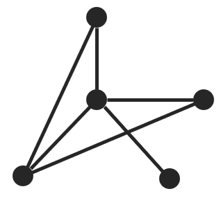

and as complex as this:

[figure not shown]

This is a co-occurrence graph of the book A Game of Thrones by George R. R. Martin where the first season of the hit TV series Game of Thrones was based on. Two characters are connected if they co-occur, that is, if their names are mentioned at most 13 words apart in the novel. The thickness of the connection is proportional to the number of co-occurrences. Data obtained in [Kaggle](https://www.kaggle.com/datasets/mmmarchetti/game-of-thrones-dataset) and plotted using [Gephi](https://gephi.org/).

**Directed graphs, weighted graphs, bipartite graphs**

The examples above already touched upon some key classifications of networks. Let us make the distinctions explicit:

1. **Directed graphs** - the connections (edges) have the information of direction
2. **Weighted graphs** - the connections (edges) have a numerical value, usually pertaining to the strength of connection
3. **Bipartite graphs** - there are two kinds of entities (nodes) and a restriction that an entity cannot connect with its own kind

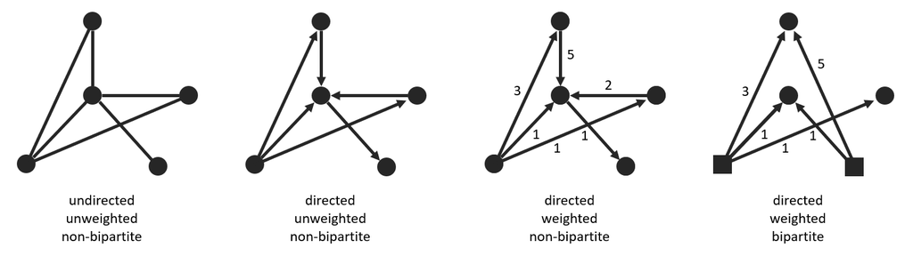

**Descriptive quantities**

What are the features that best describe networks? What metrics can be calculated from a graph that translates to real-world insights? Such quantities will be explored in the context of a **citation network**: a directed, unweighted, and non-bipartite network. In citation networks, a node represents a scientific paper and a directed edge represents a citation from one paper towards another paper. By calculating these quantities, we gain better understanding of the **effects of retraction** on the academic publishing system.

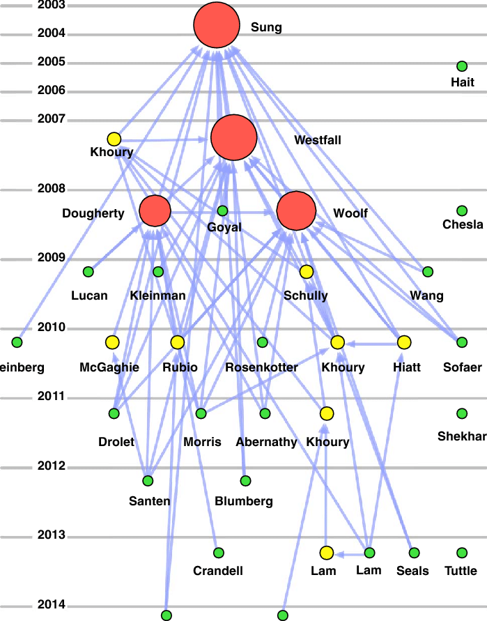

This is a citation network. The circles represent research papers (with labels referring to first authors) and the arrows represent citations. For example, first author Sung was cited by the source of all the arrows pointing to it, such as Khoury and Wang. Source: [researchgate.net](https://www.researchgate.net/figure/Directed-citation-network-Nodes-represent-papers-in-the-corpus-Directed-edges-represent_fig2_313265540)

### Data Source

The data comes from [**SNAP Datasets**](https://snap.stanford.edu/data/index.html), a collection of large-scale network data from different disciplines stored in text format. Particularly, you may visit the [**High-energy physics theory citation network**](https://snap.stanford.edu/data/cit-HepTh.html) page which contains data for the citation network of theoretical high energy physics papers in the open-access hub [**Arxiv**](https://arxiv.org/).

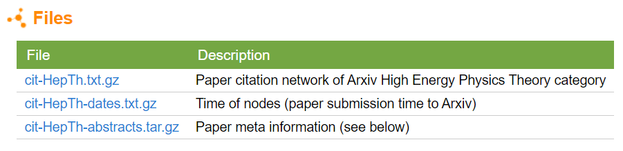

Screenshot from the High-energy physics theory citation network dataset.

There are three downloadable files in the Files section of the page. We will only use `cit-HepTh.txt.gz`. The `.gz` extension indicates that the file has been compressed; to extract its contents, we use the `gzip` module from Python's standard library:

```python
import gzip

input_file = r"C:\Users\63926\Desktop\cit-HepTh.txt.gz"
output_file = r"C:\Users\63926\Desktop\cit-HepTh.txt"

with gzip.open(input_file, 'rb') as f_in:
    file_content = f_in.read()

with open(output_file, 'wb') as f_out:
    f_out.write(file_content)
```

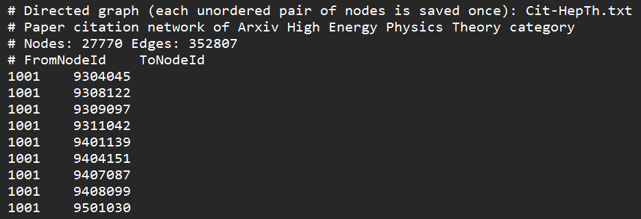

Screenshot of the contents of the text file.

Let us put the data in a NumPy array. For first-time users, [**NumPy**](https://numpy.org/) is a famous Python library for manipulating arrays and matrices. You may install it using

```python
!pip install numpy
```

We then import the library and load the data using the `np.loadtxt` function. The argument `comments='#'` removes the first few lines of the text file, leaving only the ID values.

```python
import numpy as np

edge_list = np.loadtxt(gzip.open(input_file, 'rb'), dtype=int, comments='#')
edge_list
```

```
array([[   1001, 9304045],
       [   1001, 9308122],
       [   1001, 9309097],
       ...,
       [9912286, 9808140],
       [9912286, 9810068],
       [9912286, 9901023]])
```

**Advanced analytics**

The file `cit-HepTh-dates.txt.gz` contains the information of paper submission dates. This is useful for more advanced explorations involving time dynamics. The file `cit-HepTh-abstracts.tar.gz` contains the abstracts of the papers, and could be an interesting entry point for natural language processing and topic modelling.

### Analysis and Insights

We need two more Python libraries: one to calculate the descriptive quantities and another to plot them. For these purposes, we install and import the [**NetworkX**](https://networkx.org/) and [**Matplotlib**](https://matplotlib.org/) libraries:

```python
!pip install networkx
!pip install matplotlib
```

```python
import networkx as nx
from matplotlib import pyplot as plt
```

To transform the edge list to a NetworkX graph object, I used the `nx.DiGraph` function to create an empty directed graph. Iterating over the entries of the edge list, I added each entry to the empty graph by applying the `DiGraph.add_edge` method. Despite its name, this function also adds the nodes together with the edge to the graph.

```python
G = nx.DiGraph()

for from_node, to_node in edge_list:
    G.add_edge(from_node, to_node)
```

**Size, order, network scale**

```python
N = G.order()
L = G.size()

print ('Number of nodes: ', N)
print ('Number of edges: ', L)
```

```
Number of nodes:  27770
Number of edges:  352807
```

**Adjacency matrix, symmetric matrix, self-loops**

The edge list is one way of mathematically representing a network. Another way is through an **adjacency matrix**, a square matrix consisting of zero and non-zero values. In this matrix which we denote by the symbol $A$, the rows and columns represent nodes, and the element $A_{ij}$ **gives the existence of an edge from node $i$ to node $j$**. A matrix element of zero means there is no edge between the nodes. In unweighted graphs, a matrix element of one means there is an edge between the nodes. In weighted graphs, a matrix element can be greater than 1, and this value represents the weight of the edge.

For undirected graphs, an edge from node $i$ to node $j$ implies the same edge from node $j$ to node $i$, that is, the connection is mutual between the two entities. This means $A_{ji}=A_{ij}$, a property of a so-called **symmetric matrix**. This flipping of rows and columns, also called the transpose of a matrix, can be easily performed in NumPy using the `.T` attribute.

Lastly, non-zero elements along the diagonal of the matrix imply a connection of an entity to itself; these are called **self-loops**. We do not expect to see self-loops in citation networks because it does not make sense for a paper to cite itself. The diagonal of a NumPy matrix can be called using the `np.diag` function.

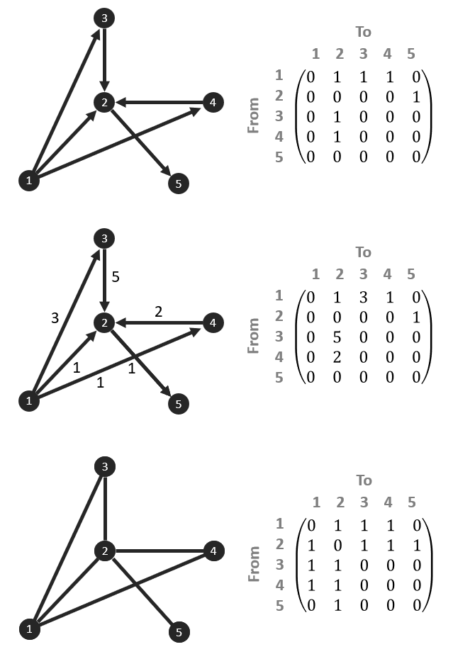

We generate the adjacency matrix using the `nx.adjacency_matrix` function.

```python
A = nx.adjacency_matrix(G).toarray()
print(f'Shape of adjacency matrix (rows, columns): {A.shape}')
print('Preview of adjacency matrix:')
A
```

```
Shape of adjacency matrix (rows, columns): (27770, 27770)
Preview of adjacency matrix:
```

```
array([[0, 1, 1, ..., 0, 0, 0],
       [0, 0, 0, ..., 0, 0, 0],
       [0, 0, 0, ..., 0, 0, 0],
       ...,
       [0, 0, 0, ..., 0, 0, 0],
       [0, 0, 0, ..., 0, 0, 0],
       [0, 0, 0, ..., 0, 0, 0]], dtype=int32)
```

The number of rows and columns of an adjacency matrix must be equal to the order. The shape of the matrix as computed by the `.shape` attribute printed above supports this.

**Directed graph, weighted graph, self-loops**

By checking the matrix elements, we quickly identify some graph properties:

- check for matrix values greater than 1 to identify if the network is weighted
- check if the matrix is symmetric to identify if the network is directed
- check if sum of diagonal elements is non-zero to detect the presence of self-loops

In the code below, I used `np.any` to check if *any* elements are greater than 1. I used `.T` to transpose the matrix and `np.all` to check if $A$ is equal to its transpose for *all* elements. Finally, I used `np.diag` to get the diagonal elements and `np.any` to check if *any* diagonal elements are non-zero.

```python
# Runtime on laptop with medium specs: less than 1 min
print(f"Weighted? {'Yes' if np.any(A > 1) else 'No'}")
print(f"Directed? {'Yes' if np.all(A == A.T) else 'No'}")
print(f"Self-loops? {'Yes' if np.any(np.diag(A) > 0) else 'No'}")
print(f"Number of self-loops: {(np.diag(A) > 0).sum()}")
```

[output not shown]

*Degree, in-degree, out-degree*

The network size and order tells us that there are 352807 edges / 27770 nodes $\approx$ 13 edges per node *on average*. Is this enough to describe the citation network? Not quite, because there will be papers that will get more citations than others. It would be nice if we knew how many papers get an impressive number and how many get a mediocre, or even zero, number of citations. The **degree** of a node refers to the number of edges connected to a node. It also refers to the number of **neighbors** of the node, that is, the number of nodes that are an edge apart from the node in question. For directed graphs, there is further distinction between **in-degree** and **out-degree** which refer to the number of edges pointing towards and away from a node, respectively.

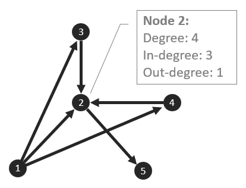

We use the `DiGraph.degree`, `DiGraph.in_degree`, and `DiGraph.out_degree` attributes to generate lists of degrees, in-degrees, and out-degrees. We also use several NumPy functions to calculate the minimum, maximum, and average values of degrees over the whole network. We also use `np.histogram` and `plt.bar` to plot the **histogram of degree values**. Feel free to increase the value of the `bins` parameter to increase the resolution of a distribution.

```
Minimum degree: 1
Maximum degree: 2468
Average degree: 25.409
```

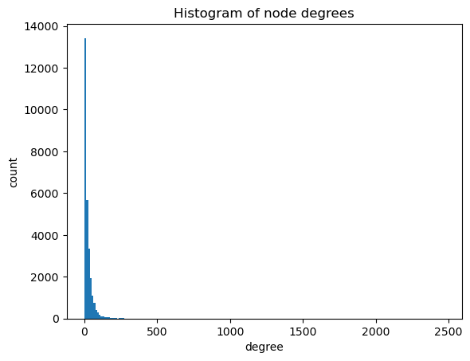

```python
ks = list(dict(G.degree).values())

k_min = np.min(ks)
k_max = np.max(ks)
k_avg = np.mean(ks)

print(f'Minimum degree: {k_min}')
print(f'Maximum degree: {k_max}')
print(f'Average degree: {k_avg:.3f}')

hist_values, bin_edges = np.histogram(ks, bins=200)
plt.bar(bin_edges[:-1], hist_values, width=np.diff(bin_edges), align='edge')
plt.xlabel('degree')
plt.ylabel('count')
plt.title('Histogram of node degrees');
```

```
Minimum degree: 0
Maximum degree: 2414
Average degree: 12.705
```

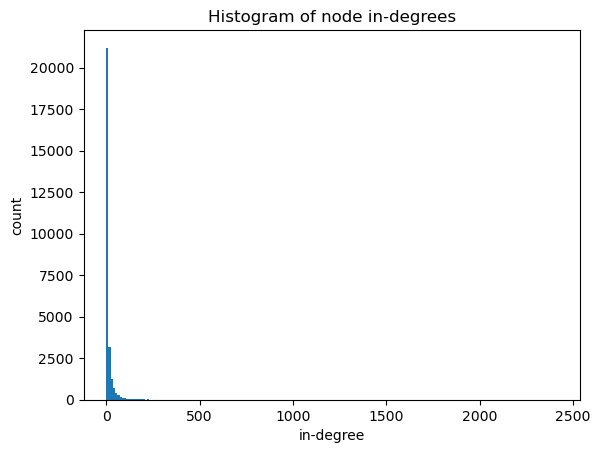

```python
ks = list(dict(G.in_degree).values())

k_min = np.min(ks)
k_max = np.max(ks)
k_avg = np.mean(ks)

print(f'Minimum degree: {k_min}')
print(f'Maximum degree: {k_max}')
print(f'Average degree: {k_avg:.3f}')

hist_values, bin_edges = np.histogram(ks, bins=200)
plt.bar(bin_edges[:-1], hist_values, width=np.diff(bin_edges), align='edge')
plt.xlabel('in-degree')
plt.ylabel('count')
plt.title('Histogram of node in-degrees');
```

```
Minimum degree: 0
Maximum degree: 562
Average degree: 12.705
```

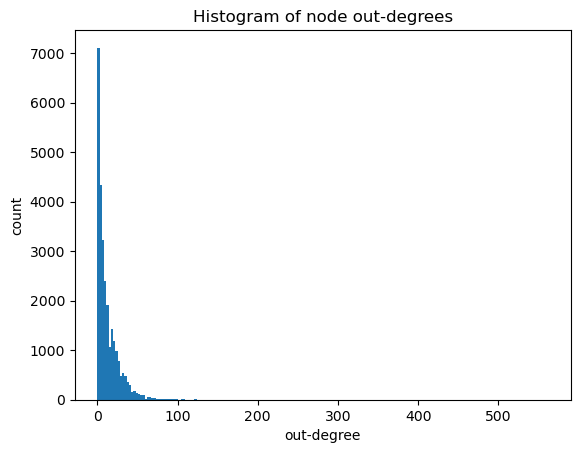

```python
ks = list(dict(G.out_degree).values())

k_min = np.min(ks)
k_max = np.max(ks)
k_avg = np.mean(ks)

print(f'Minimum degree: {k_min}')
print(f'Maximum degree: {k_max}')
print(f'Average degree: {k_avg:.3f}')

hist_values, bin_edges = np.histogram(ks, bins=200)
plt.bar(bin_edges[:-1], hist_values, width=np.diff(bin_edges), align='edge')
plt.xlabel('out-degree')
plt.ylabel('count')
plt.title('Histogram of node out-degrees');
```

*Degree distribution, small world, power law*

The histogram of node degrees, also known as **degree distribution**, looks like a decaying function. In complexity science, researchers are always on the look out for networks that exhibit **small-world** properties, i.e. emergent properties of networks that lie somewhere between the classifications of regular networks and random networks. One of these properties came from a [**paper from Albert-László Barabási and Réka Albert**](https://arxiv.org/pdf/cond-mat/9907038) when they discovered that the degree distribution of the World Wide Web followed a **power law** distribution, challenging the previous belief that networks tend to have normal (bell curve) distributions. For networks following the power law distribution, entities with few connections appear very frequently, while entities with numerous connections occur much less often.

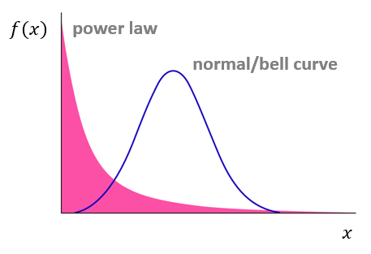

If the in-degree distribution of the citation network demonstrates this small-world property$^\dagger$, keeping in mind that the in-degree of a node is the paper's number of citations, then **very few papers would cause a significant retraction impact on their primary citations**. This insight is mum about the effect of retraction on the *secondary citations* (i.e. those who cited the primary citers) and other papers across the citation web. As a very artificial but plausible example, what if the retracted paper was cited only once but the citer was cited a thousand times? *Did the low in-degree reflect the importance of the node?* This calls for a more sophisticated metric that would better quantify the effects of retraction.

$^\dagger$*It turns out that proving that a distribution follows power law is not as straightforward as one would expect. The **Appendix** shows how to use the `powerlaw` Python module to test for goodness of power-law fit.*

**Path length, strongly connected, weakly connected**

A path is a chain of edges connecting two nodes. For a directed graph, the edges must all be pointing to the destination, that is, you can only cross the arrows of the graph from tail to head. The **path length** between two nodes in an unweighted graph is the number of edges that connect the nodes. Since there can be many paths that connect two nodes, we are often concerned only on the **shortest path length**. We also want to know the *longest* shortest path length among all pairs of nodes; this is called the **diameter** of the network.

These quantities are defined only if there is at least one path connecting any pair of nodes. A network that satisfies this is called a **strongly connected network**. Unfortunately, using the `nx.is_strongly_connected` function confirms that the citation network is not strongly connected. Simply put, there are papers that are not connected by a trail of citations. What if we allow crossing an arrow in reverse? This is equivalent to removing the direction in the edges of the graph. If there is now at least one path connecting any pair of nodes, then the network is **weakly connected**. The `nx.is_weakly_connected` function confirms that the citation network is not weakly connected.

What does this tell us about the citation network? It means **there is a limit to the impact of retracted papers**. The trace of citation will encounter unreachable nodes; these are the papers that are unaffected by the retraction.

```python
print(f"Strongly connected? {'Yes' if nx.is_strongly_connected(G) else 'No'}")
print(f"Weakly connected? {'Yes' if nx.is_weakly_connected(G) else 'No'}")
```

```
Strongly connected? No
Weakly connected? No
```

**Clustering coefficient**

The **clustering coefficient** of a node is the proportion of the node's neighbors that are connected to each other. Think about that for a bit. The higher the clustering coefficient, the more the node and its neighbors are interconnected. We use a code similar to that of the degree distribution to generate the clustering coefficient histogram below. The graph shows **generally low clustering coefficients**, with a significant number of nodes having zero clustering coefficient and very few (it is not even visible in the histogram anymore) cases of high clustering coefficient. The distribution does not seem to follow a power law, especially due to the pronounced peak at $cc$ = 0.5.

The fact that most values fall on the lower end of the clustering coefficient spectrum says something about the connectivity of the citation network. It means that there are no tightly connected groups. In such groups, when one paper is retracted, the rest of the papers within its group will be affected. **If a paper with a high clustering coefficient is retracted, its neighbors who not only cited the retracted paper but also cited each other face a greater risk of correction or retraction**. Most of the nodes in the citation network do not have this problem.

```
Minimum clustering coefficient: 0.0
Maximum clustering coefficient: 1.0
Average clustering coefficient: 0.157
```

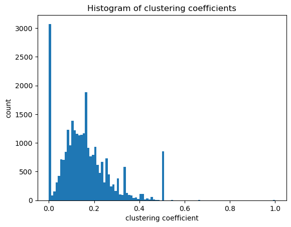

```python
cc = list(dict(nx.clustering(G)).values())

cc_min = np.min(cc)
cc_max = np.max(cc)
cc_ave = np.mean(cc)

print(f'Minimum clustering coefficient: {cc_min}')
print(f'Maximum clustering coefficient: {cc_max}')
print(f'Average clustering coefficient: {cc_ave:.3f}')

hist_values, bin_edges = np.histogram(cc, bins=100)
plt.bar(bin_edges[:-1], hist_values, width=np.diff(bin_edges), align='edge')
plt.xlabel('clustering coefficient')
plt.ylabel('count')
plt.title('Histogram of clustering coefficients');
```

**Degree centrality, betweenness centrality, closeness centrality**

There are several metrics that attempt to quantify the importance of a node. These metrics differ in what they consider as important. For example, the **degree centrality** is the node degree multiplied by some normalization constant. A node with high degree centrality would be a node that has many **neighbors.

Another metric is called the **betweenness centrality**, which measures the number of shortest paths that pass through a given node (the actual formula is slightly more complicated, but if you ignore cases where there are multiple shortest paths between two nodes, then the given definition is accurate). A node with high betweenness centrality acts as a "bridge" that connects numerous nodes and clusters.

**Closeness centrality** is the reciprocal of the sum of shortest paths from a node to all other nodes. A node with high closeness centrality would be a node that is close to all other nodes on average.

Although NetworkX has the necessary functions to compute for these values, it can no longer handle the number of computations due to the size of our dataset. Hence we turn to [**NetworKit**](https://networkit.github.io/), a high-performance Python library specifically designed to handle large networks. I have listed down my first impressions below, but both libraries should be in a network science enthusiast's toolkit.

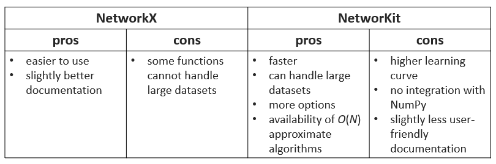

One disadvantage of NetworKit is the lack of integration with NumPy. Hence we can't use the edge list and adjacency matrix that we have saved earlier. Luckily, NetworKit can read the text files from SNAP; just use the `nk.Format.SNAP` argument in the `nk.readGraph` function.

```python
!pip install cython
!pip install networkit
```

```python
import networkit as nk

H = nk.readGraph(r"C:\Users\63926\Desktop\Cit-HepTh_1.txt", nk.Format.SNAP)
```

Computing betweenness and closeness centralities can take a lot of time since it needs to compute the shortest path for each pair of nodes in the network. Such algorithms are $O(N^2)$ in time, meaning the runtime increases according to the square of the network order. This is significant for large-scale networks, including our $N$ = 27,770 citation network. A very important advantage of NetworKit is it has algorithms that give an approximation of the betweenness and closeness centralities in an $O(L)$ time complexity, where $L$ is the network size or the number of edges. We do have to run the algorithm many times and take the average of the results to get more robust values.

Using the `nk.centrality.EstimateBetweenness` function with 10000 samples, we get the approximate histogram of betweenness centralities shown below. In my mid-spec laptop, the code ran for 5 minutes. You may decrease the number of samples if it is taking more time in your device.

```
Minimum beteweenness centrality: 0.0
Maximum beteweenness centrality: 62770454.53096331
Average beteweenness centrality: 88495.751
```

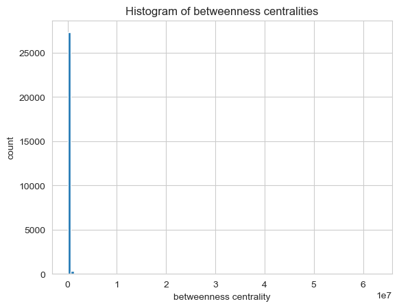

```python
B = nk.centrality.EstimateBetweenness(H, 10000)
B.run()
Bs = B.scores()

B_min = np.min(Bs)
B_max = np.max(Bs)
B_ave = np.mean(Bs)

print(f'Minimum beteweenness centrality: {B_min}')
print(f'Maximum beteweenness centrality: {B_max}')
print(f'Average beteweenness centrality: {B_ave:.3f}')

hist_values, bin_edges = np.histogram(Bs, bins=100)
plt.bar(bin_edges[:-1], hist_values, width=np.diff(bin_edges), align='edge')
plt.xlabel('betweenness centrality')
plt.ylabel('count')
plt.title('Histogram of betweenness centralities');
```

The histogram looks like a very steep power law distribution. The trend becomes more apparent when we remove the values above the 99th percentile:

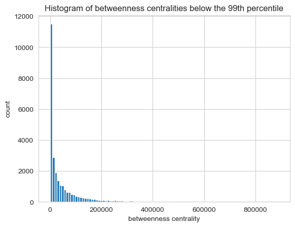

```python
Bs_99 = np.array(Bs)[Bs < np.percentile(Bs, 99)]

hist_values, bin_edges = np.histogram(Bs_99, bins=100)
plt.bar(bin_edges[:-1], hist_values, width=np.diff(bin_edges), align='edge')
plt.xlabel('betweenness centrality')
plt.ylabel('count')
plt.title('Histogram of betweenness centralities below the 99th percentile');
```

In the context of citation networks, the betweenness centrality distribution implies that there are a very small number of papers that bridge different clusters of publications. These clusters might represent subdisciplines within the subject of high energy physics. In today's modern world, papers that connect two seemingly dissimilar topics have been more prevalent than ever. These are papers that pave the way for newer multidisciplinary scholarly works. **Retracting papers with high betweenness centrality would have a devastating effect on papers from differnt subdisciplines**. If you play with the `np.percentile` function, you'll see that the 20th percentile is about 1000. This means that even nodes from the low end of the distribution still act as prominent bridges for the network.

```
Minimum closeness centrality: 3.6835837932176775e-06
Maximum closeness centrality: 1.0
Average closeness centrality: 0.003
```

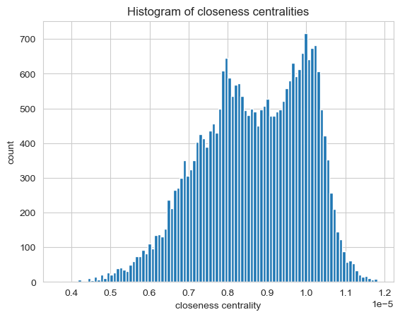

```python
C = nk.centrality.ApproxCloseness(H, 10000)
C.run()
Cs = C.scores()
Cs = np.array(Cs)[~np.isnan(Cs)]

C_min = np.min(Cs)
C_max = np.max(Cs)
C_ave = np.mean(Cs)

print(f'Minimum closeness centrality: {C_min}')
print(f'Maximum closeness centrality: {C_max}')
print(f'Average closeness centrality: {C_ave:.3f}')

Cs = Cs[Cs < np.percentile(Cs, 99)]

hist_values, bin_edges = np.histogram(Cs, bins=100)
plt.bar(bin_edges[:-1], hist_values, width=np.diff(bin_edges), align='edge')
plt.xlabel('closeness centrality')
plt.ylabel('count')
plt.title('Histogram of closeness centralities');
```

Aside from a few outliers, the closeness centralities are very small and implies that there are a large number of edges separating any two nodes on average. The calculation of closeness centralities involve taking the reciprocal of the sum of all shortest path lengths towards the node in question, so the value is bound to approach zero as you increase the network size. In the context of citation networks, a paper with a low closeness centrality are relatively isolated or have limited direct citation connections to other papers in the network. **If the impact of the retraction of papers diminishes the further you are along the trace of citations, then the low closeness centralities imply low overall impact**.

**Eigenvector centrality**

The **eigenvector centrality** measures the importance of a node by taking into account the degree of the node and its neighbors. The calculation involves solving for the eigenvector of the adjacency matrix that yields the largest eigenvalue. We would have to spend a long time studying eigenvalue and eigenvector theory to really understand the significance of this eigenvector. We simplify by saying that the compution of the eigenvector involves looking at the degree of the node in question, then the degree of its neighbors, then the degree of its neighbors' neighbors, and so on. This is the perfect metric to ascertain the importance of a paper.

Using the `nk.centrality.EigenvectorCentrality` function, we get the distribution of eigenvector centralities below. It does seem to follow a power law, meaning **very few papers have a significant effect on primary citations as well as other papers along the web of citation**. Comparing the maximum value ($\approx$0.25) with the maximum possible value which is 1, we can safely say that the impact of retractions on the papers will be moderate at most.

```
Minimum eigenvector centrality: 6.34276086516905e-107
Maximum eigenvector centrality: 0.25456455000837525
Average eigenvector centrality: 0.002
```

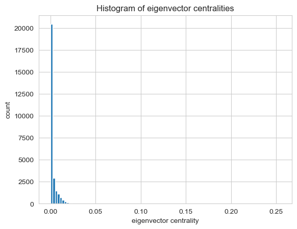

```python
E = nk.centrality.EigenvectorCentrality(H)
E.run()
Es = E.scores()

E_min = np.min(Es)
E_max = np.max(Es)
E_ave = np.mean(Es)

print(f'Minimum eigenvector centrality: {E_min}')
print(f'Maximum eigenvector centrality: {E_max}')
print(f'Average eigenvector centrality: {E_ave:.3f}')

hist_values, bin_edges = np.histogram(Es, bins=100)
plt.bar(bin_edges[:-1], hist_values, width=np.diff(bin_edges), align='edge')
plt.xlabel('eigenvector centrality')
plt.ylabel('count')
plt.title('Histogram of eigenvector centralities');
```

### Conclusion and Recommendations

In summary, the citation network demonstrates a small-world structure with a power-law degree distribution. This indicates that a few influential papers can significantly impact multiple research areas. However, the overall interconnectedness of the network is relatively low, which may limit the spread of retractions. Understanding the network structure helps us grasp the potential consequences of retractions and the importance of specific papers within the high-energy physics research domain.

It is important to note that the insights obtained from the citation network's centrality metrics, such as betweenness and closeness centrality, are most useful when compared with similar citation networks. These centrality values are relative measures that derive their significance from the network's structure and properties.

Hence, a recommendation would be to compare the computed centrality metrics with those of other citation networks. By doing so, researchers can better understand the relative importance and influence of papers within this specific network. Additionally, such comparisons can help identify outlier papers that play a critical role in connecting different subdisciplines or attracting a significant number of citations.

Considering the complexity of large-scale citation networks, a broader context and comparison with other networks can provide researchers with valuable insights into the dynamics and impact of scholarly publications within their field.

### Appendix

A very crude approach to check if a distribution follows a power law is to convert the histogram to a log-log scale. In this scale, the distribution, or at least its tail end, should fit a line. [**This paper**](https://arxiv.org/abs/0706.1062) details the correct way to check for the goodness of fit of a power law in a distribution. The gist is that the goodness of fit of a power law should always be in comparison with similar distributions and under a statistical test. [**The powerlaw library**](https://pypi.org/project/powerlaw/) implements the procedure detailed in the paper.

Fit a powerlaw on an array of raw values using the `powerlaw.Fit` class. Then use the `powerlaw.Fit.supported_distributions` and `powerlaw.Fit.distribution_compare` methods to compare the goodness of fit of the power law in the distribution compared to other decaying distributions. The comparison involves a [**Kolmogorov-Smirnov test**](https://en.wikipedia.org/wiki/Kolmogorov%E2%80%93Smirnov_test) that returns an R statistic and a p-value. A positive R statistic means the distribution is more likely power law, while a negative R statistic means the distribution is more likely to be the other distribution; the magnitude of the R statistic is proportional to the discrepancy. A p-value of less than 0.05 means a stronger evidence of discrepancy and supports the findings from R.

```python
import powerlaw

results = powerlaw.Fit(ks, discrete=False)

for i, dist in enumerate(results.supported_distributions.keys()):
    R, p = results.distribution_compare('power_law', dist)
    print(f'{dist}: R = {R}, p = {p}')
```

[output not shown]

```
Calculating best minimal value for power law fit
power_law: R = 0.0, p = 1.0
lognormal: R = 0.05524021042689009, p = 0.13614257009638084
exponential: R = 93.95461144048224, p = 3.087058081239643e-06
truncated_power_law: R = 0.00013562365521879727, p = 0.9868597645039232
stretched_exponential: R = 7.257282762115102, p = 0.0014386650390882088
lognormal_positive: R = 7.455612678203015, p = 0.00143938151009422
```

The p-value is 1 for the trivial case of comparing a power law to itself or to a truncated version. The p-value is much less than 0.05 when comparing power law with the exponential function, with the R statistic heavily favoring a power law fit. Power laws decay slower than expoential functions, so we do expect a discrepancy in how well they fit the data. The rest of the functions belong to the same family of **heavy-tailed distributions**. They are more similar to each other compared to the exponential. The p-values are still less than 0.05 for stretched expoential and log-normal positive distributions with the R statistic again favoring a power law fit. Only the comparison with log-normal yielded an inconclusive result. With these findings we are confident that the data follows a power law distribution.

### References

1. Kaiser, J. (2023, July 18). After honesty researcher's retractions, colleagues expand scrutiny of her work. Science Magazine. https://www.science.org/content/article/after-honesty-researcher-s-retractions-colleagues-expand-scrutiny-her-work
2. Stanford Daily. (2023, July 19). Stanford president resigns over manipulated research, will retract at least 3 papers. https://stanforddaily.com/2023/07/19/stanford-president-resigns-over-manipulated-research-will-retract-at-least-3-papers/
3. Shu, L. L., Mazar, N., Gino, F., & Bazerman, M. H. (2012). Signing at the beginning makes ethics salient and decreases dishonest self-reports in comparison to signing at the end. Proceedings of the National Academy of Sciences, 109(38), 15197-15200. DOI: 10.1073/pnas.1209746109.
4. Nikolaev, A., McLaughlin, T., O'Leary, D. D. M., & Tessier-Lavigne, M. (2009). APP binds DR6 to trigger axon pruning and neuron death via distinct caspases. Nature, 457(7232), 981-989. PMID: 19225519. PMCID: PMC2677572. DOI: 10.1038/nature07767.
5. The Network Science Data Repository. (2003). Cit-HepTh. Retrieved from Stanford Large Network Dataset Collection: https://snap.stanford.edu/data/cit-HepTh.html.
6. Barabási, A.-L., & Albert, R. (1999). The diameter of the world wide web. arXiv preprint cond-mat/9907038.
7. Hagberg, A., Swart, P., & S Chult, D. (2021). NetworkX Documentation. Retrieved from https://networkx.org/documentation/stable/.
8. Staudt, C. L., & Sazonovs, A. (2021). NetworKit Documentation. Retrieved from https://networkit.github.io/.
9. Clauset, A., Shalizi, C. R., & Newman, M. E. J. (2007). Power-law distributions in empirical data. arXiv preprint arXiv:0706.1062.
10. powerlaw (Version 1.4.6). (n.d.). Python Package for Power-law Distributions. Retrieved from https://pypi.org/project/powerlaw
11. Kolmogorov-Smirnov test. (n.d.). In Wikipedia. Retrieved from https://en.wikipedia.org/wiki/Kolmogorov%E2%80%93Smirnov_test